# MachineLearning

### Outlines

#### Introduction to Machine Learning

```
- Definitions, Types of learning algorithms
- Classic algorithms
    > Linear Regression, Gradient Descent,
    > Logistic Regression, Underfitting vs. overfitting, Regularization
    > Softmax Regression, General Linear Models
    > Neural Networks, DNN, CNN, RNN
    > Genetative Learning Algorithms, Naive Bayes
    > Support Vector Machines
    > Tree Models, Bagging & Boosting
    > KMeans
- Practical advices of machine learning
    > Feature engineering: feature scale, discretization, one-hot encoding
    > Hyper-parameter tuning
    > Model Selection
    > Bias vs. Variance
    > Evaluation Metrics
```

#### Practices of Machine Learning in Advertising

```
- Models used in CTR estimation
    > LR
    > GBDT + LR
    > FM, FFM
    > Wide and Deep
    > DeepFM
    > ESMM
- Current models in Noxmobi
```

### Introduction to Machine Learning

#### 1. What is Machine Learning

##### 1.1. Definitions

- Arthur Samuel (1959). Machine Learning: Field of study that gives computers the ability to learn without being explicitly programmed.
- Tom Mitchell (1998). Well-posed Learning Problem: A computer program is said to learn from experience E with respect to some task T and some performance measure P, if its performance on T, as measured by P, improves with experience, e.g:
  - T: classifying emails as spam or not
  - E: watching you label emails as spam or not
  - P: the number of fraction of emails correctly classified as spam/not spam

##### 1.2. Machine Learning vs. AI

- Artificial Intelligence is a discipline
- Machine learning is a specific way of solving AI problems

[figure not shown]

##### 1.3. Why Machine Learning

[figure not shown]

##### 1.4. Types of machine learnings

- Supervised learning
  - "right answers" given
  - Regression: predict continuous valued output; e.g., housing price prediction

[figure not shown]

  - Classification: predict discrete valued output (0 or 1); e.g., cancer detection: malignant or benign

[figure not shown]

- Unsupervised learning
  - Clustering

[figure not shown]

- Others: Reinforcement learning, Recommender systems

##### 1.5. Machine Learning Workflow

[figure not shown]

##### 1.6 Summary

- Next programming paradigm, using models instead of wrting explict rules.
- Supervised learning vs. Unsupervised learning
- Regression vs. Classification
- Train with examples first, then predict unseen data

#### 2. Linear Regression

##### 2.1. Training set & Notations

[figure not shown]

##### 2.2. Hypothesis & Cost function

[figure not shown]

##### 2.3. Gradient Descent & Learning rate

[figure not shown]

- Batch gradient descent
- stochastic gradient descent
- Mini-batch gradient descent

##### 2.4. Linear Regression with multiple variables

[figure not shown]

##### 2.5 Summary

- Hypothesis
- Cost function
- Gradient descent

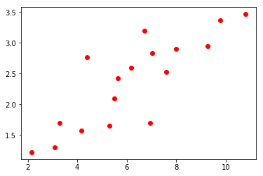

```python
# Linear Regression Demo

import tensorflow as tf
import numpy
import matplotlib.pyplot as plt

%pylab inline

rng = numpy.random

# Training Data
train_X = numpy.asarray([3.3,4.4,5.5,6.71,6.93,4.168,9.779,6.182,7.59,2.167,
                         7.042,10.791,5.313,7.997,5.654,9.27,3.1])
train_Y = numpy.asarray([1.7,2.76,2.09,3.19,1.694,1.573,3.366,2.596,2.53,1.221,
                         2.827,3.465,1.65,2.904,2.42,2.94,1.3])
n_samples = train_X.shape[0]

#Graphic display
plt.plot(train_X, train_Y, 'ro', label='data')
plt.show()
```

```
Epoch: 0100 cost= 0.106462002 W= 0.34569797 b= 0.11009829
Epoch: 0200 cost= 0.100037247 W= 0.33460638 b= 0.18989053
Epoch: 0300 cost= 0.095011540 W= 0.32479483 b= 0.26047426
Epoch: 0400 cost= 0.091080487 W= 0.31611562 b= 0.32291174
Epoch: 0500 cost= 0.088005789 W= 0.30843812 b= 0.37814263
Epoch: 0600 cost= 0.085601002 W= 0.3016469 b= 0.42699894
Epoch: 0700 cost= 0.083720304 W= 0.29563928 b= 0.47021744
Epoch: 0800 cost= 0.082249589 W= 0.29032505 b= 0.5084473
Epoch: 0900 cost= 0.081099555 W= 0.28562406 b= 0.5422661
Epoch: 1000 cost= 0.080200344 W= 0.2814655 b= 0.5721821
Optimization Finished!
Training cost= 0.080200344 W= 0.2814655 b= 0.5721821
```

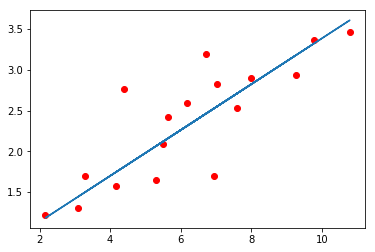

```python
# Parameters
learning_rate = 0.01
training_epochs = 1000
display_step = 100

# tf Graph Input
X = tf.placeholder("float")
Y = tf.placeholder("float")

# Set model weights
W = tf.Variable(rng.randn(), name="weight")
b = tf.Variable(rng.randn(), name="bias")

# Construct a linear model
pred = tf.add(tf.multiply(X, W), b)
# Mean squared error
cost = tf.reduce_sum(tf.pow(pred - Y, 2)) / (2 * n_samples)
# Gradient descent
optimizer = tf.train.GradientDescentOptimizer(learning_rate).minimize(cost)

# Initialize the variables (i.e. assign their default value)
init = tf.global_variables_initializer()

# Start training
with tf.Session() as sess:
    sess.run(init)

    # Fit all training data
    for epoch in range(training_epochs):
        for (x, y) in zip(train_X, train_Y):
            sess.run(optimizer, feed_dict={X: x, Y: y})

        #Display logs per epoch step
        if (epoch+1) % display_step == 0:
            c = sess.run(cost, feed_dict={X: train_X, Y:train_Y})
            print("Epoch:", '%04d' % (epoch+1), "cost=", "{:.9f}".format(c), \
                "W=", sess.run(W), "b=", sess.run(b))



    print("Optimization Finished!")
    training_cost, W_value, b_value = sess.run([cost, W, b], feed_dict={X: train_X, Y: train_Y})
    print("Training cost=", training_cost, "W=", W_value, "b=", b_value, '\n')


#Graphic display
plt.plot(train_X, train_Y, 'ro', label='Original data')
plt.plot(train_X, W_value * train_X + b_value, label='Fitted line')
plt.show()
```

#### 3. Logistic Regression

##### 3.1. Hypothesis representation

[figure not shown]

##### 3.2. Decision boundary

[figure not shown]

##### 3.3. Cost function

[figure not shown]

##### 3.4. Gradient Descent

[figure not shown]

##### 3.5 Overfitting vs. Underfitting

[figure not shown]

##### 3.6 Regularization

[figure not shown]

##### 3.7 Summary

- Hypothesis, Sigmoid function
- Decision boundary
- Cost function, Gradient descent
- Underfit vs. Overfit
- Regularization

#### 4. Nerual Networks

##### 4.1. Nerual Network Examples

- Standard NN
- Convolutional NN
- Recurrent NN

[figure not shown]

##### 4.2. Nerual Network Representation

[figure not shown]

##### 4.3. Activation Functions

[figure not shown]

- Why no-linear activation functions?

[figure not shown]

##### 4.4. Computation Graph of Logistic Regression, Forward popagation & Backward popagation

[figure not shown]

##### 4.5. Gradient descent for Neural Networks

[figure not shown]

##### 4.6. Why Neural Networks

demo1:LR

demo1:LR+cross feature

demo1:1 Neural Network

demo2: Neural Networks

#### 5. DNN: Deep Neural Network

##### 5.1. Deep Neural Network

[figure not shown]

##### 5.2. Why is Deep Learning taking off?

[figure not shown]

##### 5.3. Dropout Regularization

[figure not shown]

- Dropout intuition: do not rely on any one feature, spread out weights

##### 5.4. Vanishing/exploding gradients

##### 5.5. Optimization Algorithms

- Gradient descent with momentum
- RMSprop
- Adam optimization algorithm
- Learning rate decay

##### 5.6. Batch Normalization

##### 5.7. Transfer Learning

##### 5.8. Multi-task Learning

##### 5.9. End-to-end Deep Learning

#### 6. CNN: Convolutional Neural Network

##### Practical Advises I: Feature Scaling

[figure not shown]

- Get every feature into approximately a [-1, 1] range
- Mean normalization

[figure not shown]

##### Practical Advises II: Gradient descent debugging & Learning rate tunning

[figure not shown]

- If learning rate is too small: slow convergence.
- If learning rate is too large: may not decrease on every iteration; may not converge.

##### Practical Advises III: Model Selection

- Training/validation/test sets
- Evaluate your hypothesis

[figure not shown]

- Training/validation/test errors

[figure not shown]

- K-fold

##### Practical Advises IV: Diagnosing bias vs. variance, Learning curves

- Bias Vs. Variance

[figure not shown]

- Learning curves

[figure not shown]

- Diagnose bias/variance by earning curves

[figure not shown]

- What should do next?

[figure not shown]

- Large data rational

[figure not shown]

- Basic recipe for machine learning

[figure not shown]

- Bias and Variance with mismatched data distributions

##### Practical Advises V: Evaluation Metrics

- Precision & recall
  - Skewed classes, e.g, cancer classification, only 0.50% of patients have cancer

[figure not shown]

- Precison recall tradeoff

[figure not shown]

- F1 score

[figure not shown]

- ROC, AUC
- Satisficing and optimizing metrics
- Comparing to human-level performance
  - Avoidable bias

### Practices of Machine Learning in Avertising

#### 1. Introduction to RTB

##### 1.1. How RTB works

[figure not shown]

- RTB: Real-time Bidding
- Supply side platforms (SSP) serve publishers by registering their inventories (impressions) from multiple ad networks and accepting bids and placing ads automatically
- Adexchanges(ADX) combine multiple adnetworks together. When publishers request ads with a given context to serve users, the ADX contacts candidate Ad Networks (ADN) in real-time for a wider selection of relevant ads
- Demand side platforms (DSP) serve advertisers or ad agencies by bidding for their campaigns in multiple ad networks automatically
- Data exchanges(DX), also called Data Management Platforms(DMP), serve DSP, SSP and ADX by providing user historical data (usually in real-time) for better matching

##### 1.2. Bidding Process

[figure not shown]

##### 1.3. Example of CTR estimation

[figure not shown]

#### 2. Models used in CTR estimation

##### 2.1. Logistic Regression

[figure not shown]

##### 2.2. GBDT + LR

[figure not shown]

- Facebook, 2014

##### 2.3. FM, FFM

- FM: Factorization Machines

[figure not shown]

- FFM: Field aware Factorization Machines

[figure not shown]

##### 2.5. Wide and Deep

[figure not shown]

- Google, 2016
- Wide: memorization
- Deep: generalization

##### 2.4. DeepFM

[figure not shown]

##### 2.6. ESMM

[figure not shown]

- ESMM: Entire Space Multi-Task Model, An Effective Approach for Estimating Post-Click Conversion Rate
- Alibaba, 2018
- Elimiante 2 problems:
  1. sample selection bias
  2. data sparsity